```python
from tensorflow.keras import backend as K
import gc
K.clear_session()
gc.collect()
```

```
WARNING:tensorflow:From C:\Users\NIDHI KAPADIYA\anaconda3\envs\py39\lib\site-packages\keras\src\backend\common\global_state.py:82: The name tf.reset_default_graph is deprecated. Please use tf.compat.v1.reset_default_graph instead.
```

```
0
```

# Sounds of Seattle Birds

- Goal is to predict bird species based on sound using Neural Network.
- There are three parts:
1. Binary classification on any 2 species.
2. Multiclass classification on 12 species.
3. External data test on best model obtained form multiclass training.

## Starting with data exploration

### EDA

```python
import pandas as pd
import seaborn as sns
import matplotlib.pyplot as plt
```

```python
df = pd.read_csv("E:\\Spring Quarter 2025\\SML2\\Homework3\\bird_metadata.csv")
df.head(5)
```

|  | Unnamed: 0 | rating | playback_used | ebird_code | channels | date | duration | filename | species | title | ... | xc_id | url | country | author | primary_label | longitude | time | recordist | license | fpath |
| --- | --- | --- | --- | --- | --- | --- | --- | --- | --- | --- | --- | --- | --- | --- | --- | --- | --- | --- | --- | --- | --- |
| 0 | 166 | 5.0 | no | amecro | 2 (stereo) | 2020-07-12 | 44 | XC575220.mp3 | American Crow | XC575220 American Crow (Corvus brachyrhynchos) | ... | 575220 | https://www.xeno-canto.org/575220 | United States | Michael Hurben | Corvus brachyrhynchos_American Crow | -93.37860 | 06:00 | Michael Hurben | Creative Commons Attribution-NonCommercial-Sha... | dozenspecies/amecro/XC575220.mp3 |
| 1 | 169 | 5.0 | no | amecro | 2 (stereo) | 2020-06-17 | 41 | XC569711.mp3 | American Crow | XC569711 American Crow (Corvus brachyrhynchos ... | ... | 569711 | https://www.xeno-canto.org/569711 | United States | Russ Wigh | Corvus brachyrhynchos_American Crow | -81.05590 | 15:00 | Russ Wigh | Creative Commons Attribution-NonCommercial-Sha... | dozenspecies/amecro/XC569711.mp3 |
| 2 | 171 | 5.0 | no | amecro | 1 (mono) | 2020-06-14 | 78 | XC568365.mp3 | American Crow | XC568365 American Crow (Corvus brachyrhynchos ... | ... | 568365 | https://www.xeno-canto.org/568365 | United States | Russ Wigh | Corvus brachyrhynchos_American Crow | -81.05590 | 07:00 | Russ Wigh | Creative Commons Attribution-NonCommercial-Sha... | dozenspecies/amecro/XC568365.mp3 |
| 3 | 173 | 5.0 | no | amecro | 2 (stereo) | 0000-00-00 | 52 | XC561291.mp3 | American Crow | XC561291 American Crow (Corvus brachyrhynchos) | ... | 561291 | https://www.xeno-canto.org/561291 | United States | Jim Berry | Corvus brachyrhynchos_American Crow | -79.23810 | 06:00 | Jim Berry | Creative Commons Attribution-NonCommercial-Sha... | dozenspecies/amecro/XC561291.mp3 |
| 4 | 174 | 5.0 | no | amecro | 1 (mono) | 2019-04-18 | 13 | XC556240.mp3 | American Crow | XC556240 American Crow (Corvus brachyrhynchos) | ... | 556240 | https://www.xeno-canto.org/556240 | United States | Caio Brito | Corvus brachyrhynchos_American Crow | -81.40509 | 18:35 | Caio Brito | Creative Commons Attribution-NonCommercial-Sha... | dozenspecies/amecro/XC556240.mp3 |

5 rows × 31 columns

```python
df.describe()
```

|  | Unnamed: 0 | rating | duration | latitude | background | xc_id | longitude |
| --- | --- | --- | --- | --- | --- | --- | --- |
| count | 1981.000000 | 1981.000000 | 1981.000000 | 1956.000000 | 0.0 | 1981.000000 | 1956.000000 |
| mean | 12029.902070 | 3.858152 | 51.772842 | 38.171789 | NaN | 361785.941949 | -71.628008 |
| std | 7054.574167 | 0.680590 | 72.745494 | 13.832487 | NaN | 162729.163296 | 54.181736 |
| min | 166.000000 | 3.000000 | 3.000000 | -41.204000 | NaN | 11446.000000 | -165.405300 |
| 25% | 7042.000000 | 3.000000 | 15.000000 | 33.901850 | NaN | 199496.000000 | -114.157275 |
| 50% | 11493.000000 | 4.000000 | 31.000000 | 39.654900 | NaN | 364400.000000 | -88.113450 |
| 75% | 19033.000000 | 4.000000 | 60.000000 | 45.876750 | NaN | 533616.000000 | -7.630300 |
| max | 22783.000000 | 5.000000 | 846.000000 | 69.577800 | NaN | 588021.000000 | 153.139800 |

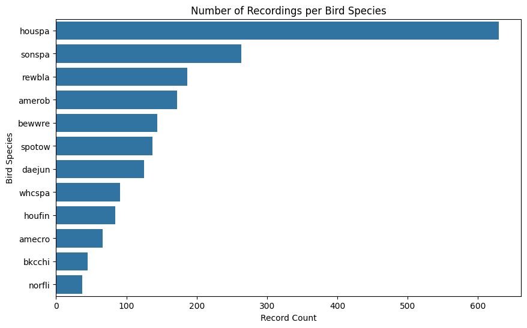

```python
# Samples per class
plt.figure(figsize=(10,6))
sns.countplot(y='ebird_code', data=df, order=df['ebird_code'].value_counts().index)
plt.title('Number of Recordings per Bird Species')
plt.xlabel('Record Count')
plt.ylabel('Bird Species')
plt.show()
```

- From the plot, majority samples are of house sparrow. While, Northen flicker and Black-capped chikadae is in minority class.
- We will perform binary classification on Red-winged black bird and American Robin as they have around same samples.

```python
binary_df = df[df['ebird_code'].isin(['rewbla', 'amerob'])].copy()
```

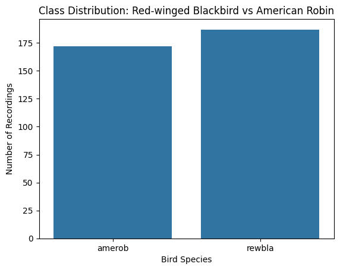

```python
sns.countplot(data=binary_df, x='ebird_code')
plt.title('Class Distribution: Red-winged Blackbird vs American Robin')
plt.xlabel('Bird Species')
plt.ylabel('Number of Recordings')
plt.show()
```

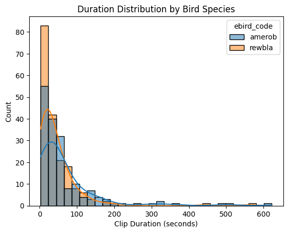

```python
sns.histplot(data=binary_df, x='duration', hue='ebird_code', bins=30, kde=True)
plt.title('Duration Distribution by Bird Species')
plt.xlabel('Clip Duration (seconds)')
plt.ylabel('Count')
plt.show()
```

## Binary Classification - CNN

### Code flow:

1. Data Preparation
2. Spliting data on 70-30
3. Building basic 3 CNN models
4. Evaluating and finding 2 best out of 3CNN models
5. Trying different batch sizes and dropout on thos 2 models
6. Discusssing Result
7. Finding best model

### Red-winged Blackbird vs American Robin

#### Step1: Load Dependencies

```python
import numpy as np
import matplotlib.pyplot as plt
import h5py
import tensorflow as tf
from sklearn.model_selection import train_test_split

from keras.models import Sequential
from keras.layers import Conv2D, MaxPooling2D, Flatten, Dense, Dropout
```

#### Step2 : Data Loading

```python
bird_sound = h5py.File("E:\\Spring Quarter 2025\\SML2\\Homework3\\bird_spectrograms.hdf5", 'r')
print(list(bird_sound.keys()))
```

```
['amecro', 'amerob', 'bewwre', 'bkcchi', 'daejun', 'houfin', 'houspa', 'norfli', 'rewbla', 'sonspa', 'spotow', 'whcspa']
```

```python
bird1 = bird_sound['amerob'][:]
bird2 = bird_sound['rewbla'][:]

print(bird1.shape)
print(bird2.shape)
```

```
(128, 517, 172)
(128, 517, 187)
```

#### Step3: Preaparing Data

```python
# Transforming data and assinging labels 0 to American robin and 1 to Red-winged Blackbird

X_bird1= np.transpose(bird1,(2, 0, 1))
X_bird2 = np.transpose(bird2, (2, 0, 1))
y_bird1 = np.zeros(172)
y_bird2 = np.ones(187)
```

```python
# Concaenating both species data
X = np.concatenate([X_bird1, X_bird2],axis=0)
y = np.concatenate([y_bird1,y_bird2],axis=0)
```

```python
X = X.reshape((359, 128, 517, 1))
print(X.shape)
```

```
(359, 128, 517, 1)
```

### Step4: Train-Test Split

```python
# Splitting data into 70-30 for training and testing
X_train, X_test, y_train, y_test = train_test_split(
    X, y, test_size=0.30, random_state=42, stratify=y)
```

### Step5 : Building Model

```python
# First binary CNN model
model1_binary = Sequential()

# Step 1 - Convolution
model1_binary.add(Conv2D(16, (3, 3), activation='relu', input_shape=(128, 517, 1)))

# Step 2 - Pooling
model1_binary.add(MaxPooling2D(pool_size=(2, 2)))

# Adding a second convolutional layer
model1_binary.add(Conv2D(32, (3, 3), activation='relu'))

# Step 3 - Flattening
model1_binary.add(Flatten())

# Step 4 - Full connection
model1_binary.add(Dense(units=64, activation='relu'))
model1_binary.add(Dropout(0.3))
model1_binary.add(Dense(units=1, activation='sigmoid'))
```

```
C:\Users\NIDHI KAPADIYA\anaconda3\envs\py39\lib\site-packages\keras\src\layers\convolutional\base_conv.py:107: UserWarning: Do not pass an `input_shape`/`input_dim` argument to a layer. When using Sequential models, prefer using an `Input(shape)` object as the first layer in the model instead.
  super().__init__(activity_regularizer=activity_regularizer, **kwargs)
```

### Step6: Training Model

```python
# Metrics are accuracy,precision,recall and auc
model1_binary.compile(
    optimizer='adam',
    loss='binary_crossentropy',
    metrics=[
        'accuracy',
        tf.keras.metrics.Precision(name='precision'),
        tf.keras.metrics.Recall(name='recall'),
        tf.keras.metrics.AUC(name='auc')
    ]
)


import time

start_time = time.time()

history1 = model1_binary.fit(
    X_train, y_train,
    epochs=50,
    batch_size=64,
    validation_data=(X_test, y_test)
)
end_time = time.time()
time1 = end_time - start_time
print(f"Training time: {time1:.2f} seconds")
```

```
4/4 ━━━━━━━━━━━━━━━━━━━━ 7s 1s/step - accuracy: 0.4915 - auc: 0.4980 - loss: 707.5485 - precision: 0.4898 - recall: 0.6092 - val_accuracy: 0.4815 - val_auc: 0.5000 - val_loss: 252.3771 - val_precision: 0.0000e+00 - val_recall: 0.0000e+00
4/4 ━━━━━━━━━━━━━━━━━━━━ 4s 1s/step - accuracy: 0.4521 - auc: 0.4577 - loss: 220.8301 - precision: 0.0000e+00 - recall: 0.0000e+00 - val_accuracy: 0.5185 - val_auc: 0.5000 - val_loss: 53.1764 - val_precision: 0.5185 - val_recall: 1.0000
4/4 ━━━━━━━━━━━━━━━━━━━━ 3s 741ms/step - accuracy: 0.4760 - auc: 0.4165 - loss: 35.9204 - precision: 0.4752 - recall: 1.0000 - val_accuracy: 0.5185 - val_auc: 0.5000 - val_loss: 19.0970 - val_precision: 0.5185 - val_recall: 1.0000
4/4 ━━━━━━━━━━━━━━━━━━━━ 3s 758ms/step - accuracy: 0.5088 - auc: 0.4878 - loss: 23.9718 - precision: 0.5132 - recall: 0.6240 - val_accuracy: 0.5000 - val_auc: 0.4935 - val_loss: 0.7070 - val_precision: 0.5114 - val_recall: 0.8036
4/4 ━━━━━━━━━━━━━━━━━━━━ 3s 778ms/step - accuracy: 0.5726 - auc: 0.5712 - loss: 4.1283 - precision: 0.5453 - recall: 0.8459 - val_accuracy: 0.4815 - val_auc: 0.5000 - val_loss: 10.3164 - val_precision: 0.0000e+00 - val_recall: 0.0000e+00
4/4 ━━━━━━━━━━━━━━━━━━━━ 4s 940ms/step - accuracy: 0.5532 - auc: 0.5359 - loss: 8.9385 - precision: 0.5595 - recall: 0.7281 - val_accuracy: 0.5000 - val_auc: 0.4811 - val_loss: 0.6941 - val_precision: 0.5094 - val_recall: 0.9643
4/4 ━━━━━━━━━━━━━━━━━━━━ 4s 963ms/step - accuracy: 0.5139 - auc: 0.4839 - loss: 1.2628 - precision: 0.5156 - recall: 0.9939 - val_accuracy: 0.4907 - val_auc: 0.4818 - val_loss: 0.6947 - val_precision: 0.5048 - val_recall: 0.9464
4/4 ━━━━━━━━━━━━━━━━━━━━ 3s 755ms/step - accuracy: 0.4531 - auc: 0.4597 - loss: 1.1508 - precision: 0.4700 - recall: 0.6710 - val_accuracy: 0.5185 - val_auc: 0.5936 - val_loss: 0.7438 - val_precision: 0.5185 - val_recall: 1.0000
4/4 ━━━━━━━━━━━━━━━━━━━━ 3s 689ms/step - accuracy: 0.5269 - auc: 0.5078 - loss: 1.0132 - precision: 0.5341 - recall: 0.7791 - val_accuracy: 0.5185 - val_auc: 0.6401 - val_loss: 0.6897 - val_precision: 0.5185 - val_recall: 1.0000
4/4 ━━━━━━━━━━━━━━━━━━━━ 7s 1s/step - accuracy: 0.5567 - auc: 0.6082 - loss: 0.6740 - precision: 0.5560 - recall: 1.0000 - val_accuracy: 0.5185 - val_auc: 0.6679 - val_loss: 0.6837 - val_precision: 0.5185 - val_recall: 1.0000
4/4 ━━━━━━━━━━━━━━━━━━━━ 6s 1s/step - accuracy: 0.5304 - auc: 0.7339 - loss: 0.6731 - precision: 0.5201 - recall: 1.0000 - val_accuracy: 0.5278 - val_auc: 0.7419 - val_loss: 0.6790 - val_precision: 0.5234 - val_recall: 1.0000
4/4 ━━━━━━━━━━━━━━━━━━━━ 4s 1s/step - accuracy: 0.6568 - auc: 0.8200 - loss: 0.6425 - precision: 0.6125 - recall: 0.9847 - val_accuracy: 0.5370 - val_auc: 0.7728 - val_loss: 0.8400 - val_precision: 1.0000 - val_recall: 0.1071
4/4 ━━━━━━━━━━━━━━━━━━━━ 5s 1s/step - accuracy: 0.6748 - auc: 0.7817 - loss: 0.6203 - precision: 0.7331 - recall: 0.5940 - val_accuracy: 0.6667 - val_auc: 0.7009 - val_loss: 0.6522 - val_precision: 0.6351 - val_recall: 0.8393
4/4 ━━━━━━━━━━━━━━━━━━━━ 6s 1s/step - accuracy: 0.8253 - auc: 0.9065 - loss: 0.3882 - precision: 0.7935 - recall: 0.9171 - val_accuracy: 0.6852 - val_auc: 0.7572 - val_loss: 0.5846 - val_precision: 0.6964 - val_recall: 0.6964
4/4 ━━━━━━━━━━━━━━━━━━━━ 4s 1s/step - accuracy: 0.9108 - auc: 0.9815 - loss: 0.2305 - precision: 0.8986 - recall: 0.9277 - val_accuracy: 0.6574 - val_auc: 0.7758 - val_loss: 0.7116 - val_precision: 0.6267 - val_recall: 0.8393
4/4 ━━━━━━━━━━━━━━━━━━━━ 4s 1s/step - accuracy: 0.9423 - auc: 0.9864 - loss: 0.1609 - precision: 0.9390 - recall: 0.9545 - val_accuracy: 0.6759 - val_auc: 0.7727 - val_loss: 0.7258 - val_precision: 0.7234 - val_recall: 0.6071
4/4 ━━━━━━━━━━━━━━━━━━━━ 6s 1s/step - accuracy: 0.9533 - auc: 0.9938 - loss: 0.1262 - precision: 0.9625 - recall: 0.9483 - val_accuracy: 0.7222 - val_auc: 0.7828 - val_loss: 0.7035 - val_precision: 0.7826 - val_recall: 0.6429
4/4 ━━━━━━━━━━━━━━━━━━━━ 5s 1s/step - accuracy: 0.9843 - auc: 0.9965 - loss: 0.0914 - precision: 0.9820 - recall: 0.9892 - val_accuracy: 0.6759 - val_auc: 0.7728 - val_loss: 0.8627 - val_precision: 0.6981 - val_recall: 0.6607
4/4 ━━━━━━━━━━━━━━━━━━━━ 4s 1s/step - accuracy: 0.9858 - auc: 0.9996 - loss: 0.0649 - precision: 1.0000 - recall: 0.9731 - val_accuracy: 0.6759 - val_auc: 0.7684 - val_loss: 1.0682 - val_precision: 0.7143 - val_recall: 0.6250
4/4 ━━━━━━━━━━━━━━━━━━━━ 5s 1s/step - accuracy: 0.9769 - auc: 0.9990 - loss: 0.0591 - precision: 0.9844 - recall: 0.9736 - val_accuracy: 0.6574 - val_auc: 0.7512 - val_loss: 1.1479 - val_precision: 0.6377 - val_recall: 0.7857
4/4 ━━━━━━━━━━━━━━━━━━━━ 5s 1s/step - accuracy: 0.9889 - auc: 0.9997 - loss: 0.0307 - precision: 0.9868 - recall: 0.9918 - val_accuracy: 0.6481 - val_auc: 0.7474 - val_loss: 1.2609 - val_precision: 0.6364 - val_recall: 0.7500
4/4 ━━━━━━━━━━━━━━━━━━━━ 5s 1s/step - accuracy: 0.9707 - auc: 0.9968 - loss: 0.0852 - precision: 0.9426 - recall: 1.0000 - val_accuracy: 0.6852 - val_auc: 0.7883 - val_loss: 0.9047 - val_precision: 0.7391 - val_recall: 0.6071
```

[output cut: 29 more lines]

```python
model1_binary.summary()
```

```
Model: "sequential"
```

```
┏━━━━━━━━━━━━━━━━━━━━━━━━━━━━━━━━━┳━━━━━━━━━━━━━━━━━━━━━━━━┳━━━━━━━━━━━━━━━┓
┃ Layer (type)                    ┃ Output Shape           ┃       Param # ┃
┡━━━━━━━━━━━━━━━━━━━━━━━━━━━━━━━━━╇━━━━━━━━━━━━━━━━━━━━━━━━╇━━━━━━━━━━━━━━━┩
│ conv2d (Conv2D)                 │ (None, 126, 515, 16)   │           160 │
├─────────────────────────────────┼────────────────────────┼───────────────┤
│ max_pooling2d (MaxPooling2D)    │ (None, 63, 257, 16)    │             0 │
├─────────────────────────────────┼────────────────────────┼───────────────┤
│ conv2d_1 (Conv2D)               │ (None, 61, 255, 32)    │         4,640 │
├─────────────────────────────────┼────────────────────────┼───────────────┤
│ flatten (Flatten)               │ (None, 497760)         │             0 │
├─────────────────────────────────┼────────────────────────┼───────────────┤
│ dense (Dense)                   │ (None, 64)             │    31,856,704 │
├─────────────────────────────────┼────────────────────────┼───────────────┤
│ dropout (Dropout)               │ (None, 64)             │             0 │
├─────────────────────────────────┼────────────────────────┼───────────────┤
│ dense_1 (Dense)                 │ (None, 1)              │            65 │
└─────────────────────────────────┴────────────────────────┴───────────────┘
```

```
 Total params: 95,584,709 (364.63 MB)
```

```
 Trainable params: 31,861,569 (121.54 MB)
```

```
 Non-trainable params: 0 (0.00 B)
```

```
 Optimizer params: 63,723,140 (243.08 MB)
```

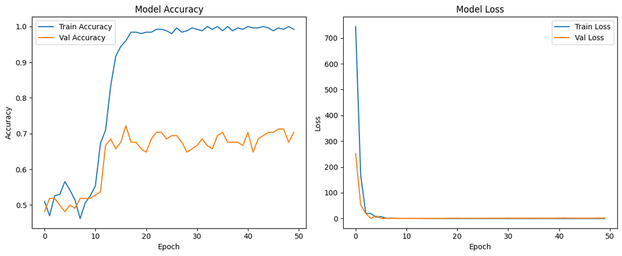

```python
plt.figure(figsize=(12, 5))

plt.subplot(1, 2, 1)
plt.plot(history1.history['accuracy'], label='Train Accuracy')
plt.plot(history1.history['val_accuracy'], label='Val Accuracy')
plt.title('Model Accuracy')
plt.xlabel('Epoch')
plt.ylabel('Accuracy')
plt.legend()

plt.subplot(1, 2, 2)
plt.plot(history1.history['loss'], label='Train Loss')
plt.plot(history1.history['val_loss'], label='Val Loss')
plt.title('Model Loss')
plt.xlabel('Epoch')
plt.ylabel('Loss')
plt.legend()

plt.tight_layout()
plt.show()
```

- After around 15 epochs, the model's training accuracy keeps improving, but validation accuracy stays around 70%.
- This means the model starts overfitting after 15 epochs, and more training does not help improve validation performance.

```
4/4 ━━━━━━━━━━━━━━━━━━━━ 1s 170ms/step - accuracy: 0.7200 - auc: 0.7796 - loss: 1.9087 - precision: 0.6886 - recall: 0.8099
Test Accuracy: 0.7037
Test Precision: 0.6765
Test Recall: 0.8214
Test AUC: 0.7618
4/4 ━━━━━━━━━━━━━━━━━━━━ 1s 210ms/step
```

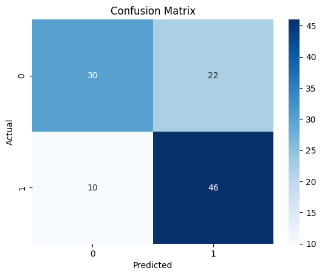

```python
from sklearn.metrics import confusion_matrix, ConfusionMatrixDisplay

loss1, accuracy1, precision1, recall1, auc1 = model1_binary.evaluate(X_test, y_test)

print(f"Test Accuracy: {accuracy1:.4f}")
print(f"Test Precision: {precision1:.4f}")
print(f"Test Recall: {recall1:.4f}")
print(f"Test AUC: {auc1:.4f}")

y_pred_probs = model1_binary.predict(X_test)
y_pred = (y_pred_probs > 0.5).astype("int32").flatten()
y_true = y_test.flatten()

cm = confusion_matrix(y_true, y_pred)
sns.heatmap(cm, annot=True, fmt='d', cmap='Blues')
plt.xlabel('Predicted')
plt.ylabel('Actual')
plt.title('Confusion Matrix')
plt.show()
```

- The heatmap shows that the model correctly predicted most Red-winged Blackbird calls (46).
- However, some American Robin samples were misclassified as Red-winged Blackbird (22).

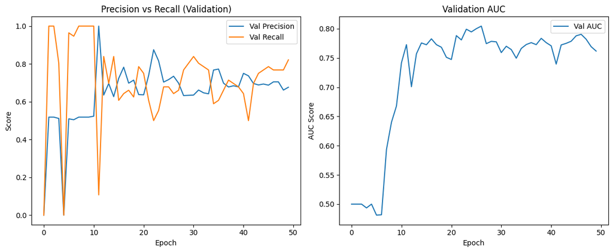

```python
plt.figure(figsize=(12, 5))
plt.subplot(1, 2, 1)
plt.plot(history1.history['val_precision'], label='Val Precision')
plt.plot(history1.history['val_recall'], label='Val Recall')
plt.title('Precision vs Recall (Validation)')
plt.xlabel('Epoch')
plt.ylabel('Score')
plt.legend()

plt.subplot(1, 2, 2)
plt.plot(history1.history['val_auc'], label='Val AUC')
plt.title('Validation AUC')
plt.xlabel('Epoch')
plt.ylabel('AUC Score')
plt.legend()

plt.tight_layout()
plt.show()
```

### CNN-Model2

```python
# Defining model
model2_binary = Sequential()
model2_binary.add(Conv2D(8, (3, 3), activation='relu', input_shape=(128, 517, 1)))
model2_binary.add(MaxPooling2D(pool_size=(2, 2)))

model2_binary.add(Conv2D(16, (3, 3), activation='relu'))
model2_binary.add(MaxPooling2D(pool_size=(2, 2)))

model2_binary.add(Flatten())
model2_binary.add(Dense(32, activation='relu'))
model2_binary.add(Dropout(0.3))
model2_binary.add(Dense(1, activation='sigmoid'))
```

```
C:\Users\NIDHI KAPADIYA\anaconda3\envs\py39\lib\site-packages\keras\src\layers\convolutional\base_conv.py:107: UserWarning: Do not pass an `input_shape`/`input_dim` argument to a layer. When using Sequential models, prefer using an `Input(shape)` object as the first layer in the model instead.
  super().__init__(activity_regularizer=activity_regularizer, **kwargs)
```

```python
model2_binary.compile(
    optimizer='adam',
    loss='binary_crossentropy',
    metrics=[
        'accuracy',
        tf.keras.metrics.Precision(name='precision'),
        tf.keras.metrics.Recall(name='recall'),
        tf.keras.metrics.AUC(name='auc')
    ]
)


start_time = time.time()

# Train the model
history2= model2_binary.fit(
    X_train, y_train,
    epochs=30,
    batch_size=64,
    validation_data=(X_test, y_test)
)
end_time = time.time()
time2 = end_time - start_time
print(f"Training time: {time2:.2f} seconds")
```

```
4/4 ━━━━━━━━━━━━━━━━━━━━ 8s 690ms/step - accuracy: 0.5106 - auc: 0.5341 - loss: 146.8463 - precision: 0.5370 - recall: 0.4138 - val_accuracy: 0.5185 - val_auc: 0.5089 - val_loss: 0.6928 - val_precision: 0.5185 - val_recall: 1.0000
4/4 ━━━━━━━━━━━━━━━━━━━━ 1s 332ms/step - accuracy: 0.5385 - auc: 0.5000 - loss: 0.6931 - precision: 0.5385 - recall: 1.0000 - val_accuracy: 0.5185 - val_auc: 0.5089 - val_loss: 0.6928 - val_precision: 0.5185 - val_recall: 1.0000
4/4 ━━━━━━━━━━━━━━━━━━━━ 2s 393ms/step - accuracy: 0.5192 - auc: 0.4983 - loss: 0.6931 - precision: 0.5192 - recall: 1.0000 - val_accuracy: 0.5185 - val_auc: 0.5089 - val_loss: 0.6928 - val_precision: 0.5185 - val_recall: 1.0000
4/4 ━━━━━━━━━━━━━━━━━━━━ 1s 329ms/step - accuracy: 0.5431 - auc: 0.5000 - loss: 0.6930 - precision: 0.5431 - recall: 1.0000 - val_accuracy: 0.5185 - val_auc: 0.5089 - val_loss: 0.6929 - val_precision: 0.5185 - val_recall: 1.0000
4/4 ━━━━━━━━━━━━━━━━━━━━ 2s 426ms/step - accuracy: 0.5020 - auc: 0.5000 - loss: 0.6931 - precision: 0.5020 - recall: 1.0000 - val_accuracy: 0.5185 - val_auc: 0.5089 - val_loss: 0.6930 - val_precision: 0.5185 - val_recall: 1.0000
4/4 ━━━━━━━━━━━━━━━━━━━━ 2s 440ms/step - accuracy: 0.5473 - auc: 0.5000 - loss: 0.6929 - precision: 0.5473 - recall: 1.0000 - val_accuracy: 0.5185 - val_auc: 0.5089 - val_loss: 0.6930 - val_precision: 0.5185 - val_recall: 1.0000
4/4 ━━━━━━━━━━━━━━━━━━━━ 2s 449ms/step - accuracy: 0.5187 - auc: 0.5113 - loss: 3.2830 - precision: 0.5186 - recall: 0.8366 - val_accuracy: 0.5185 - val_auc: 0.5089 - val_loss: 0.6930 - val_precision: 0.5185 - val_recall: 1.0000
4/4 ━━━━━━━━━━━━━━━━━━━━ 2s 451ms/step - accuracy: 0.5385 - auc: 0.5000 - loss: 0.6929 - precision: 0.5385 - recall: 1.0000 - val_accuracy: 0.5185 - val_auc: 0.5089 - val_loss: 0.6930 - val_precision: 0.5185 - val_recall: 1.0000
4/4 ━━━━━━━━━━━━━━━━━━━━ 2s 380ms/step - accuracy: 0.5254 - auc: 0.5000 - loss: 0.6929 - precision: 0.5254 - recall: 1.0000 - val_accuracy: 0.5185 - val_auc: 0.5000 - val_loss: 0.6930 - val_precision: 0.5185 - val_recall: 1.0000
4/4 ━━━━━━━━━━━━━━━━━━━━ 1s 322ms/step - accuracy: 0.5103 - auc: 0.5000 - loss: 0.6931 - precision: 0.5103 - recall: 1.0000 - val_accuracy: 0.5185 - val_auc: 0.5000 - val_loss: 0.6930 - val_precision: 0.5185 - val_recall: 1.0000
4/4 ━━━━━━━━━━━━━━━━━━━━ 1s 284ms/step - accuracy: 0.5489 - auc: 0.5000 - loss: 0.6927 - precision: 0.5489 - recall: 1.0000 - val_accuracy: 0.5185 - val_auc: 0.5000 - val_loss: 0.6930 - val_precision: 0.5185 - val_recall: 1.0000
4/4 ━━━━━━━━━━━━━━━━━━━━ 1s 226ms/step - accuracy: 0.4890 - auc: 0.5000 - loss: 0.6933 - precision: 0.4890 - recall: 1.0000 - val_accuracy: 0.5185 - val_auc: 0.5000 - val_loss: 0.6930 - val_precision: 0.5185 - val_recall: 1.0000
4/4 ━━━━━━━━━━━━━━━━━━━━ 1s 345ms/step - accuracy: 0.5317 - auc: 0.5000 - loss: 0.6928 - precision: 0.5317 - recall: 1.0000 - val_accuracy: 0.5185 - val_auc: 0.5000 - val_loss: 0.6929 - val_precision: 0.5185 - val_recall: 1.0000
4/4 ━━━━━━━━━━━━━━━━━━━━ 1s 328ms/step - accuracy: 0.5239 - auc: 0.5000 - loss: 0.6929 - precision: 0.5239 - recall: 1.0000 - val_accuracy: 0.5185 - val_auc: 0.5000 - val_loss: 0.6929 - val_precision: 0.5185 - val_recall: 1.0000
4/4 ━━━━━━━━━━━━━━━━━━━━ 1s 339ms/step - accuracy: 0.5161 - auc: 0.5000 - loss: 0.6930 - precision: 0.5161 - recall: 1.0000 - val_accuracy: 0.5185 - val_auc: 0.5000 - val_loss: 0.6929 - val_precision: 0.5185 - val_recall: 1.0000
4/4 ━━━━━━━━━━━━━━━━━━━━ 2s 404ms/step - accuracy: 0.5082 - auc: 0.5000 - loss: 0.6931 - precision: 0.5082 - recall: 1.0000 - val_accuracy: 0.5185 - val_auc: 0.5000 - val_loss: 0.6929 - val_precision: 0.5185 - val_recall: 1.0000
4/4 ━━━━━━━━━━━━━━━━━━━━ 2s 445ms/step - accuracy: 0.5624 - auc: 0.5000 - loss: 0.6923 - precision: 0.5624 - recall: 1.0000 - val_accuracy: 0.5185 - val_auc: 0.5000 - val_loss: 0.6929 - val_precision: 0.5185 - val_recall: 1.0000
4/4 ━━━━━━━━━━━━━━━━━━━━ 1s 364ms/step - accuracy: 0.5197 - auc: 0.5000 - loss: 0.6929 - precision: 0.5197 - recall: 1.0000 - val_accuracy: 0.5185 - val_auc: 0.5000 - val_loss: 0.6929 - val_precision: 0.5185 - val_recall: 1.0000
4/4 ━━━━━━━━━━━━━━━━━━━━ 2s 432ms/step - accuracy: 0.5374 - auc: 0.5000 - loss: 0.6926 - precision: 0.5374 - recall: 1.0000 - val_accuracy: 0.5185 - val_auc: 0.5000 - val_loss: 0.6929 - val_precision: 0.5185 - val_recall: 1.0000
4/4 ━━━━━━━━━━━━━━━━━━━━ 1s 374ms/step - accuracy: 0.5218 - auc: 0.5000 - loss: 0.6928 - precision: 0.5218 - recall: 1.0000 - val_accuracy: 0.5185 - val_auc: 0.5000 - val_loss: 0.6929 - val_precision: 0.5185 - val_recall: 1.0000
```

[output cut: 11 more lines]

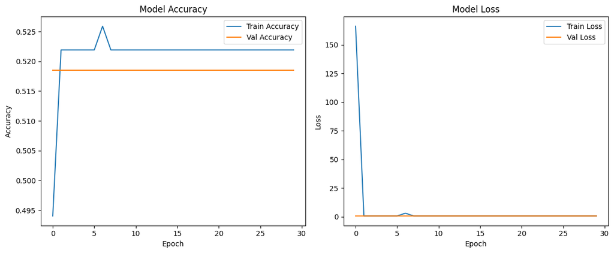

```python
plt.figure(figsize=(12, 5))

plt.subplot(1, 2, 1)
plt.plot(history2.history['accuracy'], label='Train Accuracy')
plt.plot(history2.history['val_accuracy'], label='Val Accuracy')
plt.title('Model Accuracy')
plt.xlabel('Epoch')
plt.ylabel('Accuracy')
plt.legend()

plt.subplot(1, 2, 2)
plt.plot(history2.history['loss'], label='Train Loss')
plt.plot(history2.history['val_loss'], label='Val Loss')
plt.title('Model Loss')
plt.xlabel('Epoch')
plt.ylabel('Loss')
plt.legend()

plt.tight_layout()
plt.show()
```

- The model's training and validation accuracy are both around 52%, meaning it's not learning for all epochs.

```
4/4 ━━━━━━━━━━━━━━━━━━━━ 0s 41ms/step - accuracy: 0.5022 - auc: 0.5000 - loss: 0.6932 - precision: 0.5022 - recall: 1.0000
Test Accuracy: 0.5185
Test Precision: 0.5185
Test Recall: 1.0000
Test AUC: 0.5000
4/4 ━━━━━━━━━━━━━━━━━━━━ 0s 52ms/step
```

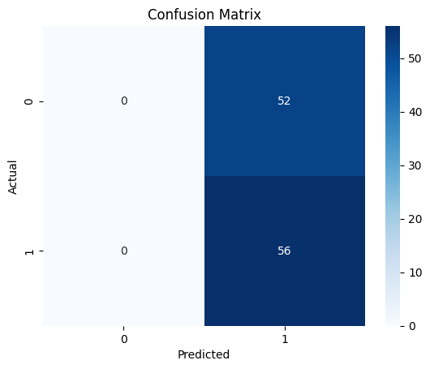

```python
loss1, accuracy1, precision1, recall1, auc1 = model2_binary.evaluate(X_test, y_test)

print(f"Test Accuracy: {accuracy1:.4f}")
print(f"Test Precision: {precision1:.4f}")
print(f"Test Recall: {recall1:.4f}")
print(f"Test AUC: {auc1:.4f}")

y_pred_probs = model2_binary.predict(X_test)
y_pred = (y_pred_probs > 0.5).astype("int32").flatten()
y_true = y_test.flatten()

cm = confusion_matrix(y_true, y_pred)
sns.heatmap(cm, annot=True, fmt='d', cmap='Blues')
plt.xlabel('Predicted')
plt.ylabel('Actual')
plt.title('Confusion Matrix')
plt.show()
```

- All the samples classified as Red-Winged Blackbird suggesting this model is not performing well.

### CNN- Model3

```python
# Defining model
model3_binary = Sequential()
model3_binary.add(Conv2D(32, (3, 3), activation='relu', input_shape=(128, 517, 1)))
model3_binary.add(MaxPooling2D(pool_size=(2, 2)))

model3_binary.add(Conv2D(64, (3, 3), activation='relu'))
model3_binary.add(MaxPooling2D(pool_size=(2, 2)))

model3_binary.add(Flatten())
model3_binary.add(Dense(128, activation='relu'))
model3_binary.add(Dropout(0.3))
model3_binary.add(Dense(1, activation='sigmoid'))
```

```
C:\Users\NIDHI KAPADIYA\anaconda3\envs\py39\lib\site-packages\keras\src\layers\convolutional\base_conv.py:107: UserWarning: Do not pass an `input_shape`/`input_dim` argument to a layer. When using Sequential models, prefer using an `Input(shape)` object as the first layer in the model instead.
  super().__init__(activity_regularizer=activity_regularizer, **kwargs)
```

```python
model3_binary.compile(
    optimizer='adam',
    loss='binary_crossentropy',
    metrics=[
        'accuracy',
        tf.keras.metrics.Precision(name='precision'),
        tf.keras.metrics.Recall(name='recall'),
        tf.keras.metrics.AUC(name='auc')
    ]
)

start_time = time.time()

history3= model3_binary.fit(
    X_train, y_train,
    epochs=30,
    batch_size=64,
    validation_data=(X_test, y_test)
)
end_time = time.time()
time3 = end_time - start_time
print(f"Training time: {time3:.2f} seconds")
```

```
4/4 ━━━━━━━━━━━━━━━━━━━━ 19s 4s/step - accuracy: 0.4917 - auc: 0.5135 - loss: 296.4748 - precision: 0.5266 - recall: 0.4075 - val_accuracy: 0.5185 - val_auc: 0.5000 - val_loss: 75.1613 - val_precision: 0.5185 - val_recall: 1.0000
4/4 ━━━━━━━━━━━━━━━━━━━━ 10s 3s/step - accuracy: 0.5249 - auc: 0.5265 - loss: 56.5760 - precision: 0.5194 - recall: 0.9095 - val_accuracy: 0.4907 - val_auc: 0.5019 - val_loss: 0.8928 - val_precision: 0.6000 - val_recall: 0.0536
4/4 ━━━━━━━━━━━━━━━━━━━━ 11s 2s/step - accuracy: 0.4385 - auc: 0.4686 - loss: 8.0707 - precision: 0.4917 - recall: 0.3801 - val_accuracy: 0.6389 - val_auc: 0.7160 - val_loss: 0.6668 - val_precision: 0.6104 - val_recall: 0.8393
4/4 ━━━━━━━━━━━━━━━━━━━━ 10s 3s/step - accuracy: 0.6946 - auc: 0.6854 - loss: 0.8393 - precision: 0.6713 - recall: 0.8223 - val_accuracy: 0.5648 - val_auc: 0.6690 - val_loss: 0.7297 - val_precision: 0.7368 - val_recall: 0.2500
4/4 ━━━━━━━━━━━━━━━━━━━━ 6s 2s/step - accuracy: 0.8277 - auc: 0.9082 - loss: 0.5156 - precision: 0.8769 - recall: 0.7821 - val_accuracy: 0.5370 - val_auc: 0.6784 - val_loss: 0.7821 - val_precision: 0.8750 - val_recall: 0.1250
4/4 ━━━━━━━━━━━━━━━━━━━━ 9s 3s/step - accuracy: 0.7480 - auc: 0.8430 - loss: 0.5499 - precision: 0.8437 - recall: 0.6606 - val_accuracy: 0.4815 - val_auc: 0.7296 - val_loss: 1.1133 - val_precision: 0.0000e+00 - val_recall: 0.0000e+00
4/4 ━━━━━━━━━━━━━━━━━━━━ 9s 2s/step - accuracy: 0.6530 - auc: 0.7938 - loss: 0.6571 - precision: 0.7748 - recall: 0.5999 - val_accuracy: 0.6852 - val_auc: 0.6575 - val_loss: 0.6804 - val_precision: 0.6719 - val_recall: 0.7679
4/4 ━━━━━━━━━━━━━━━━━━━━ 8s 2s/step - accuracy: 0.9094 - auc: 0.9647 - loss: 0.3482 - precision: 0.8885 - recall: 0.9406 - val_accuracy: 0.6759 - val_auc: 0.6581 - val_loss: 0.9746 - val_precision: 0.6296 - val_recall: 0.9107
4/4 ━━━━━━━━━━━━━━━━━━━━ 8s 2s/step - accuracy: 0.8736 - auc: 0.9812 - loss: 0.2767 - precision: 0.8101 - recall: 1.0000 - val_accuracy: 0.6852 - val_auc: 0.6793 - val_loss: 0.7082 - val_precision: 0.6667 - val_recall: 0.7857
4/4 ━━━━━━━━━━━━━━━━━━━━ 9s 2s/step - accuracy: 0.9601 - auc: 0.9922 - loss: 0.1798 - precision: 0.9320 - recall: 0.9969 - val_accuracy: 0.4907 - val_auc: 0.6044 - val_loss: 4.0195 - val_precision: 1.0000 - val_recall: 0.0179
4/4 ━━━━━━━━━━━━━━━━━━━━ 8s 2s/step - accuracy: 0.7811 - auc: 0.9194 - loss: 0.6985 - precision: 0.9061 - recall: 0.6608 - val_accuracy: 0.6389 - val_auc: 0.7385 - val_loss: 1.6781 - val_precision: 1.0000 - val_recall: 0.3036
4/4 ━━━━━━━━━━━━━━━━━━━━ 9s 2s/step - accuracy: 0.9634 - auc: 0.9967 - loss: 0.1097 - precision: 1.0000 - recall: 0.9254 - val_accuracy: 0.6574 - val_auc: 0.7109 - val_loss: 0.6994 - val_precision: 0.6727 - val_recall: 0.6607
4/4 ━━━━━━━━━━━━━━━━━━━━ 6s 2s/step - accuracy: 1.0000 - auc: 1.0000 - loss: 0.0834 - precision: 1.0000 - recall: 1.0000 - val_accuracy: 0.6481 - val_auc: 0.6884 - val_loss: 0.9071 - val_precision: 0.6667 - val_recall: 0.6429
4/4 ━━━━━━━━━━━━━━━━━━━━ 10s 2s/step - accuracy: 0.9968 - auc: 1.0000 - loss: 0.0434 - precision: 0.9940 - recall: 1.0000 - val_accuracy: 0.6296 - val_auc: 0.7148 - val_loss: 1.6698 - val_precision: 0.7857 - val_recall: 0.3929
4/4 ━━━━━━━━━━━━━━━━━━━━ 8s 2s/step - accuracy: 0.9927 - auc: 0.9994 - loss: 0.0311 - precision: 1.0000 - recall: 0.9850 - val_accuracy: 0.6389 - val_auc: 0.7373 - val_loss: 1.3296 - val_precision: 0.7576 - val_recall: 0.4464
4/4 ━━━━━━━━━━━━━━━━━━━━ 8s 2s/step - accuracy: 1.0000 - auc: 1.0000 - loss: 0.0161 - precision: 1.0000 - recall: 1.0000 - val_accuracy: 0.6667 - val_auc: 0.7335 - val_loss: 1.1323 - val_precision: 0.7174 - val_recall: 0.5893
4/4 ━━━━━━━━━━━━━━━━━━━━ 11s 3s/step - accuracy: 1.0000 - auc: 1.0000 - loss: 0.0130 - precision: 1.0000 - recall: 1.0000 - val_accuracy: 0.6667 - val_auc: 0.7399 - val_loss: 1.1568 - val_precision: 0.6923 - val_recall: 0.6429
4/4 ━━━━━━━━━━━━━━━━━━━━ 8s 2s/step - accuracy: 1.0000 - auc: 1.0000 - loss: 0.0111 - precision: 1.0000 - recall: 1.0000 - val_accuracy: 0.6852 - val_auc: 0.7625 - val_loss: 1.2971 - val_precision: 0.7750 - val_recall: 0.5536
4/4 ━━━━━━━━━━━━━━━━━━━━ 9s 2s/step - accuracy: 1.0000 - auc: 1.0000 - loss: 0.0045 - precision: 1.0000 - recall: 1.0000 - val_accuracy: 0.6759 - val_auc: 0.7490 - val_loss: 1.6417 - val_precision: 0.8387 - val_recall: 0.4643
4/4 ━━━━━━━━━━━━━━━━━━━━ 9s 2s/step - accuracy: 1.0000 - auc: 1.0000 - loss: 0.0040 - precision: 1.0000 - recall: 1.0000 - val_accuracy: 0.6574 - val_auc: 0.7643 - val_loss: 1.7229 - val_precision: 0.8065 - val_recall: 0.4464
```

[output cut: 11 more lines]

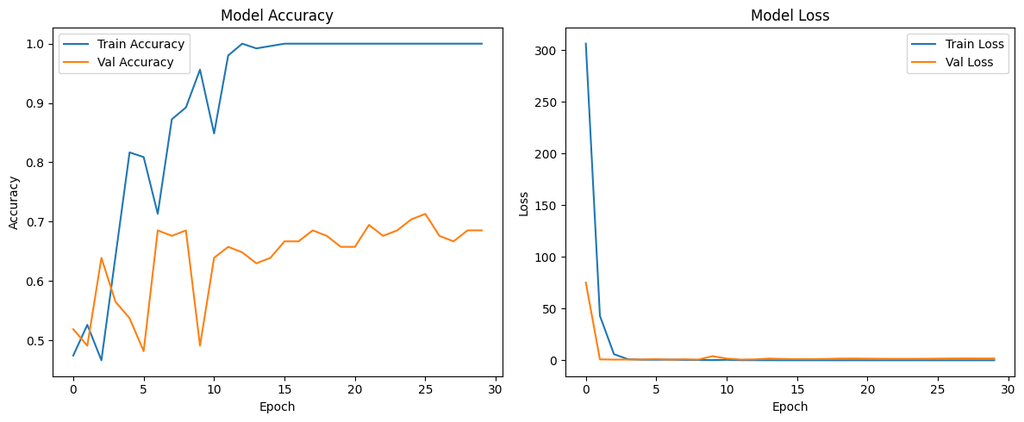

```python
plt.figure(figsize=(12, 5))

plt.subplot(1, 2, 1)
plt.plot(history3.history['accuracy'], label='Train Accuracy')
plt.plot(history3.history['val_accuracy'], label='Val Accuracy')
plt.title('Model Accuracy')
plt.xlabel('Epoch')
plt.ylabel('Accuracy')
plt.legend()

plt.subplot(1, 2, 2)
plt.plot(history3.history['loss'], label='Train Loss')
plt.plot(history3.history['val_loss'], label='Val Loss')
plt.title('Model Loss')
plt.xlabel('Epoch')
plt.ylabel('Loss')
plt.legend()

plt.tight_layout()
plt.show()
```

- The model reaches nearly perfect training accuracy, but validation accuracy stays around 0.65-0.70 and becomes plateau after 25.
- This means the model is overfitting — it learns the training data too well but doesn’t generalize to new data.

```
4/4 ━━━━━━━━━━━━━━━━━━━━ 1s 183ms/step - accuracy: 0.7189 - auc: 0.7684 - loss: 1.8712 - precision: 0.7607 - recall: 0.6468
Test Accuracy: 0.6852
Test Precision: 0.7292
Test Recall: 0.6250
Test AUC: 0.7577
WARNING:tensorflow:5 out of the last 9 calls to <function TensorFlowTrainer.make_predict_function.<locals>.one_step_on_data_distributed at 0x0000017C7E6321F0> triggered tf.function retracing. Tracing is expensive and the excessive number of tracings could be due to (1) creating @tf.function repeated…
WARNING:tensorflow:6 out of the last 12 calls to <function TensorFlowTrainer.make_predict_function.<locals>.one_step_on_data_distributed at 0x0000017C7E6321F0> triggered tf.function retracing. Tracing is expensive and the excessive number of tracings could be due to (1) creating @tf.function repeate…
4/4 ━━━━━━━━━━━━━━━━━━━━ 1s 203ms/step
```

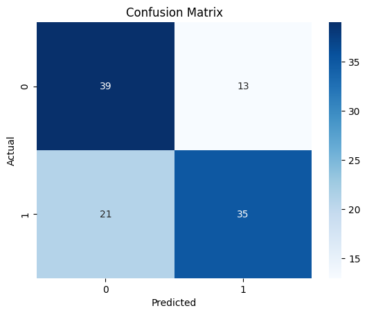

```python
loss1, accuracy1, precision1, recall1, auc1 = model3_binary.evaluate(X_test, y_test)

print(f"Test Accuracy: {accuracy1:.4f}")
print(f"Test Precision: {precision1:.4f}")
print(f"Test Recall: {recall1:.4f}")
print(f"Test AUC: {auc1:.4f}")

y_pred_probs = model3_binary.predict(X_test)
y_pred = (y_pred_probs > 0.5).astype("int32").flatten()
y_true = y_test.flatten()

cm = confusion_matrix(y_true, y_pred)
sns.heatmap(cm, annot=True, fmt='d', cmap='Blues')
plt.xlabel('Predicted')
plt.ylabel('Actual')
plt.title('Confusion Matrix')
plt.show()
```

- The heatmap shows that the model correctly predicted most American Robin (39).
- However, some American Robin samples were misclassified as Red-winged Blackbird (13).

## Tunning Model- CNN Model1

- Out of three cnn model, model1 and model3 performed well.
- So, I am tunning that models atarting with model1 which was good in predicting Red-Winged Blakbird.
- Trying with three different batch sizes and 2 different dropout rates.
- Keeping epoch 15, as we seen from first CNN model1 that it is not improving after 15 epochs.

```python
import time
from tensorflow.keras import backend as K
import gc

# Trying 3 different batch sizes and 2 different dropout rates
batch_sizes = [16, 32, 64]
dropout_rates = [0.2, 0.4]

results1 = []
history_records1 = {}

for batch_size in batch_sizes:
    for dropout_rate in dropout_rates:
        model_name = f"bs{batch_size}_do{int(dropout_rate*10)}"
        print(f"\nTraining with batch_size={batch_size}, dropout_rate={dropout_rate}")

        # Clear session and memory
        K.clear_session()
        gc.collect()

        # Build the model
        model = Sequential()
        model.add(Conv2D(16, (3, 3), activation='relu', input_shape=(128, 517, 1)))
        model.add(MaxPooling2D(pool_size=(2, 2)))
        model.add(Conv2D(32, (3, 3), activation='relu'))
        model.add(MaxPooling2D(pool_size=(2, 2)))
        model.add(Flatten())
        model.add(Dense(64, activation='relu'))
        model.add(Dropout(dropout_rate))
        model.add(Dense(1, activation='sigmoid'))

        model.compile(
            optimizer='adam',
            loss='binary_crossentropy',
            metrics=[
                'accuracy',
                tf.keras.metrics.Precision(name='precision'),
                tf.keras.metrics.Recall(name='recall'),
                tf.keras.metrics.AUC(name='auc')
            ]
        )


        start_time = time.time()

        history5 = model.fit(
            X_train, y_train,
            epochs=15,
            batch_size=batch_size,
            validation_data=(X_test, y_test),
            verbose=0
        )

        elapsed_time = time.time() - start_time
        print(f"Training time: {elapsed_time:.2f} seconds")


        history_records1[model_name] = history5.history
        scores = model.evaluate(X_test, y_test, verbose=0)
        results1.append({
            'model': model_name,
            'batch_size': batch_size,
            'dropout_rate': dropout_rate,
            'val_accuracy': scores[1],
            'val_precision': scores[2],
            'val_recall': scores[3],
            'val_auc': scores[4],
            'training_time_sec': elapsed_time
        })
```

```
Training with batch_size=16, dropout_rate=0.2
Training time: 53.83 seconds

Training with batch_size=16, dropout_rate=0.4
Training time: 54.83 seconds

Training with batch_size=32, dropout_rate=0.2
Training time: 43.24 seconds

Training with batch_size=32, dropout_rate=0.4
Training time: 42.31 seconds

Training with batch_size=64, dropout_rate=0.2
Training time: 40.77 seconds

Training with batch_size=64, dropout_rate=0.4
Training time: 38.44 seconds
```

- All variaiation of CNN model1 trained under 1 minute, which is reasonable time.

```python
# Print results sorted by validation accuracy
results_sorted = sorted(results1, key=lambda x: x['val_accuracy'], reverse=True)
for r in results_sorted:
    print(r)
```

```
{'model': 'bs16_do4', 'batch_size': 16, 'dropout_rate': 0.4, 'val_accuracy': 0.7037037014961243, 'val_precision': 0.7142857313156128, 'val_recall': 0.7142857313156128, 'val_auc': 0.8027129173278809, 'training_time_sec': 54.82879424095154}
{'model': 'bs32_do4', 'batch_size': 32, 'dropout_rate': 0.4, 'val_accuracy': 0.6944444179534912, 'val_precision': 0.7804877758026123, 'val_recall': 0.5714285969734192, 'val_auc': 0.7723214626312256, 'training_time_sec': 42.31474852561951}
{'model': 'bs16_do2', 'batch_size': 16, 'dropout_rate': 0.2, 'val_accuracy': 0.6388888955116272, 'val_precision': 0.6491228342056274, 'val_recall': 0.6607142686843872, 'val_auc': 0.7699175477027893, 'training_time_sec': 53.829193115234375}
{'model': 'bs32_do2', 'batch_size': 32, 'dropout_rate': 0.2, 'val_accuracy': 0.6296296119689941, 'val_precision': 0.6818181872367859, 'val_recall': 0.5357142686843872, 'val_auc': 0.7032967209815979, 'training_time_sec': 43.23538064956665}
{'model': 'bs64_do4', 'batch_size': 64, 'dropout_rate': 0.4, 'val_accuracy': 0.5092592835426331, 'val_precision': 0.514018714427948, 'val_recall': 0.9821428656578064, 'val_auc': 0.4910714328289032, 'training_time_sec': 38.43986797332764}
{'model': 'bs64_do2', 'batch_size': 64, 'dropout_rate': 0.2, 'val_accuracy': 0.48148149251937866, 'val_precision': 0.0, 'val_recall': 0.0, 'val_auc': 0.509615421295166, 'training_time_sec': 40.77443170547485}
```

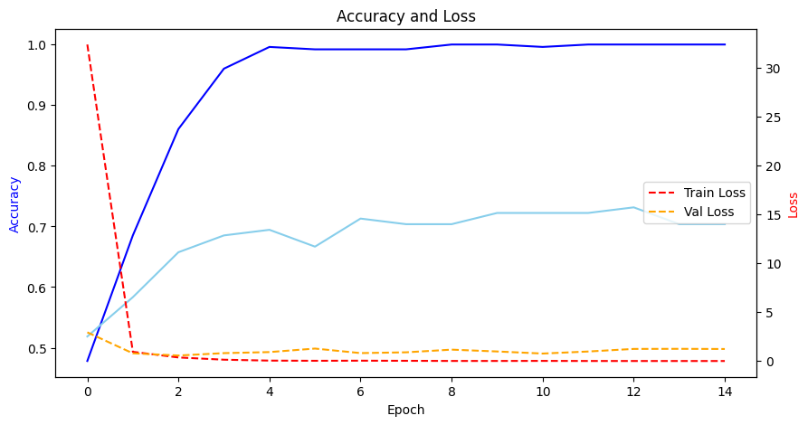

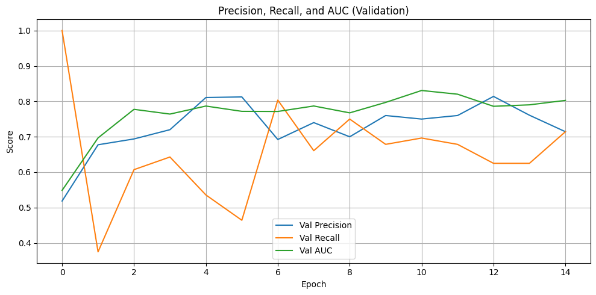

```python
best_history=history_records1['bs16_do4']
plt.figure(figsize=(10, 5))
plt.title('Accuracy and Loss')
plt.xlabel('Epoch')

plt.plot(best_history['accuracy'], label='Train Accuracy', color='blue')
plt.plot(best_history['val_accuracy'], label='Val Accuracy', color='skyblue')

plt.ylabel('Accuracy', color='blue')
plt.twinx()
plt.plot(best_history['loss'], label='Train Loss', color='red', linestyle='--')
plt.plot(best_history['val_loss'], label='Val Loss', color='orange', linestyle='--')
plt.ylabel('Loss', color='red')
plt.legend(loc='center right')
plt.show()


plt.figure(figsize=(10, 5))
plt.plot(best_history['val_precision'], label='Val Precision')
plt.plot(best_history['val_recall'], label='Val Recall')
plt.plot(best_history['val_auc'], label='Val AUC')
plt.title('Precision, Recall, and AUC (Validation)')
plt.xlabel('Epoch')
plt.ylabel('Score')
plt.legend(loc='lower center')
plt.grid(True)
plt.tight_layout()
plt.show()
```

- Validation accuracy is around 0.7, and AUC at 0.80, meaning the model predicts both classes well.

```python
import time
# Grid of batch sizes and dropout rates
batch_sizes = [16, 32, 64]
dropout_rates = [0.2, 0.4]

results2 = []
history_records2 = {}

for batch_size in batch_sizes:
    for dropout_rate in dropout_rates:
        model_name = f"bs{batch_size}_do{int(dropout_rate*10)}"
        print(f"Training with batch_size={batch_size}, dropout_rate={dropout_rate}")

        # Clear session and memory
        K.clear_session()
        gc.collect()

        # Build the model
        model = Sequential()
        model.add(Conv2D(32, (3, 3), activation='relu', input_shape=(128, 517, 1)))
        model.add(MaxPooling2D(pool_size=(2, 2)))
        model.add(Conv2D(64, (3, 3), activation='relu'))
        model.add(MaxPooling2D(pool_size=(2, 2)))
        model.add(Flatten())
        model.add(Dense(128, activation='relu'))
        model.add(Dropout(dropout_rate))
        model.add(Dense(1, activation='sigmoid'))

        model.compile(
            optimizer='adam',
            loss='binary_crossentropy',
            metrics=[
                'accuracy',
                tf.keras.metrics.Precision(name='precision'),
                tf.keras.metrics.Recall(name='recall'),
                tf.keras.metrics.AUC(name='auc')
            ]
        )

        # Measure training time
        start_time = time.time()

        history = model.fit(
            X_train, y_train,
            epochs=15,
            batch_size=batch_size,
            validation_data=(X_test, y_test),
            verbose=0
        )

        elapsed_time = time.time() - start_time
        print(f"Training time: {elapsed_time:.2f} seconds")

        # Save results
        history_records2[model_name] = history.history
        scores = model.evaluate(X_test, y_test, verbose=0)
        results2.append({
            'config': model_name,
            'batch_size': batch_size,
            'dropout_rate': dropout_rate,
            'val_accuracy': scores[1],
            'val_precision': scores[2],
            'val_recall': scores[3],
            'val_auc': scores[4],
            'training_time_sec': elapsed_time
        })
```

```
Training with batch_size=16, dropout_rate=0.2
Training time: 155.51 seconds
Training with batch_size=16, dropout_rate=0.4
Training time: 158.51 seconds
Training with batch_size=32, dropout_rate=0.2
Training time: 141.91 seconds
Training with batch_size=32, dropout_rate=0.4
Training time: 137.51 seconds
Training with batch_size=64, dropout_rate=0.2
Training time: 125.60 seconds
Training with batch_size=64, dropout_rate=0.4
Training time: 128.76 seconds
```

```python
# Print results sorted by validation accuracy
results_sorted2 = sorted(results2, key=lambda x: x['val_accuracy'], reverse=True)
for r in results_sorted2:
    print(r)
```

```
{'config': 'bs16_do4', 'batch_size': 16, 'dropout_rate': 0.4, 'val_accuracy': 0.7222222089767456, 'val_precision': 0.7599999904632568, 'val_recall': 0.6785714030265808, 'val_auc': 0.7867444753646851, 'training_time_sec': 158.51228523254395}
{'config': 'bs64_do2', 'batch_size': 64, 'dropout_rate': 0.2, 'val_accuracy': 0.7129629850387573, 'val_precision': 0.7358490824699402, 'val_recall': 0.6964285969734192, 'val_auc': 0.776785671710968, 'training_time_sec': 125.60413551330566}
{'config': 'bs32_do4', 'batch_size': 32, 'dropout_rate': 0.4, 'val_accuracy': 0.6944444179534912, 'val_precision': 0.7446808218955994, 'val_recall': 0.625, 'val_auc': 0.7251030206680298, 'training_time_sec': 137.50552988052368}
{'config': 'bs64_do4', 'batch_size': 64, 'dropout_rate': 0.4, 'val_accuracy': 0.6574074029922485, 'val_precision': 0.7021276354789734, 'val_recall': 0.5892857313156128, 'val_auc': 0.738839328289032, 'training_time_sec': 128.75587511062622}
{'config': 'bs16_do2', 'batch_size': 16, 'dropout_rate': 0.2, 'val_accuracy': 0.6111111044883728, 'val_precision': 0.6944444179534912, 'val_recall': 0.4464285671710968, 'val_auc': 0.7141139507293701, 'training_time_sec': 155.51334524154663}
{'config': 'bs32_do2', 'batch_size': 32, 'dropout_rate': 0.2, 'val_accuracy': 0.6018518805503845, 'val_precision': 0.6857143044471741, 'val_recall': 0.4285714328289032, 'val_auc': 0.7367788553237915, 'training_time_sec': 141.91226601600647}
```

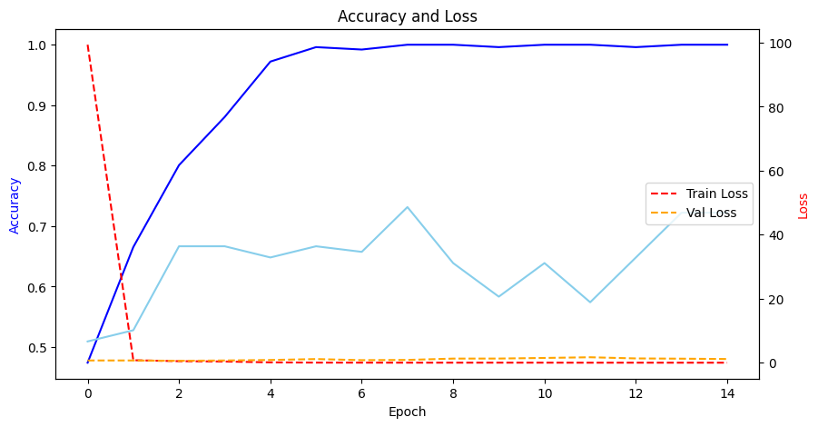

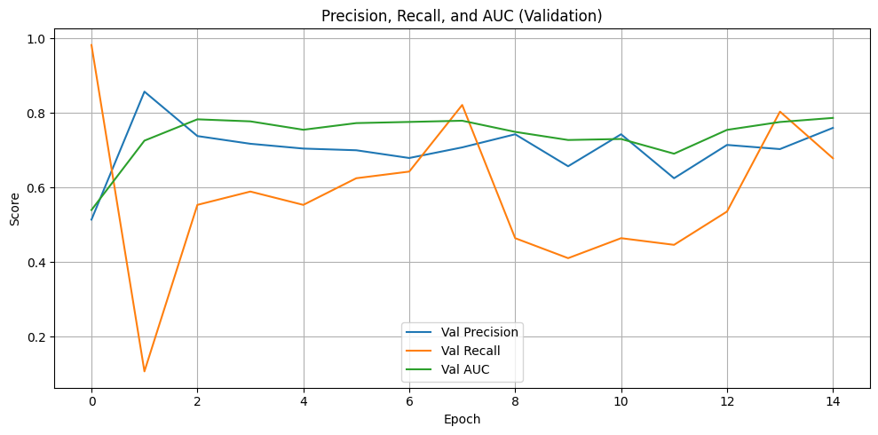

```python
best_history=history_records2['bs16_do4']
plt.figure(figsize=(10, 5))
plt.title('Accuracy and Loss')
plt.xlabel('Epoch')

plt.plot(best_history['accuracy'], label='Train Accuracy', color='blue')
plt.plot(best_history['val_accuracy'], label='Val Accuracy', color='skyblue')

plt.ylabel('Accuracy', color='blue')
plt.twinx()
plt.plot(best_history['loss'], label='Train Loss', color='red', linestyle='--')
plt.plot(best_history['val_loss'], label='Val Loss', color='orange', linestyle='--')
plt.ylabel('Loss', color='red')
plt.legend(loc='center right')
plt.show()


plt.figure(figsize=(10, 5))
plt.plot(best_history['val_precision'], label='Val Precision')
plt.plot(best_history['val_recall'], label='Val Recall')
plt.plot(best_history['val_auc'], label='Val AUC')
plt.title('Precision, Recall, and AUC (Validation)')
plt.xlabel('Epoch')
plt.ylabel('Score')
plt.legend(loc='lower center')
plt.grid(True)
plt.tight_layout()
plt.show()
```